# compile-regional-data

#### Coho

Coho salmon spawner abundances in the Skeena were expanded from available spawner surveys, as described below in Expansion Factors. Note that the designation of indicator streams for the Skeena region was based on English et al. (2018) rather than the indicator designation in NuSEDS. **Purple open circles are escapement data from Table 32 of Joint Northern Boundary Technical Report (Joint Northern Boundary Technical Committee 2026) for comparison.**

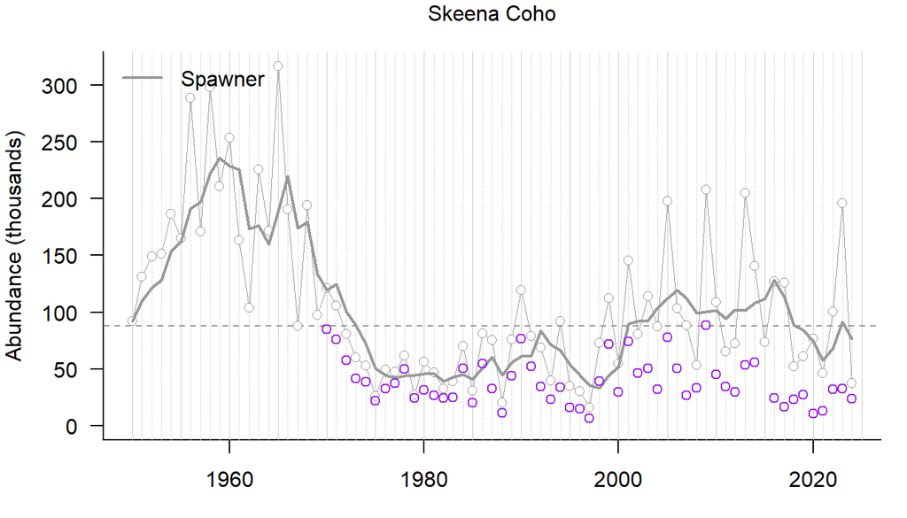

**Above:** Spawner abundance of Skeena coho salmon. The raw data is shown by points and the smoothed metric by solid lines. Dashed horizonal lines represent the long-term average.

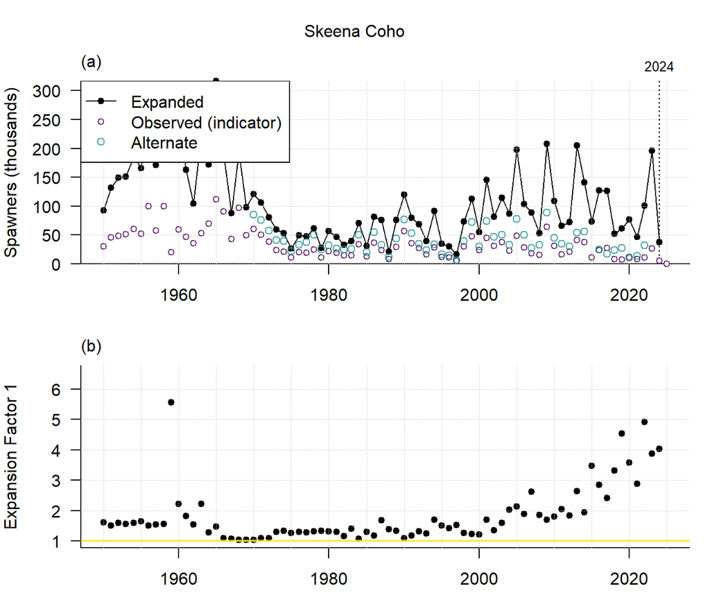

**Above:** (a) Time series of spawner abundances showing raw sum of counts for indicator streams (purple) and expanded estimates of spawner abudnance to indicator and non-indicator streams (black). This expanded time series is what is used to assess the current state and trends in spawner abundance for the region and species. Alternative time series from the PSC’s Northern Boundary Technical Committee Report (Appendix 32) is shown in blue. (b) The values of Expansion Factor 1 that accounts for unmonitored indicator streams in a given year, and is calculated based on the proportional contribution of the unmonitored indicator stream(s) to the sum of all indicator streams in a (reference) decade. See section on Expansion Factors below for further details.

```r
## Process data
skeena.s <- sp[2, "Coho", ]
skeena.s <- skeena.s[!is.na(skeena.s)]

# Reformat data for SPS
skeena.s_sps <- data.frame(
    region = rep("Skeena", length(skeena.s)),
    species = rep("Coho", length(skeena.s)),
    year = as.numeric(names(skeena.s)),
    spawners = as.numeric(skeena.s),
    smoothedSpawners = NA,
    runsize = NA,
    smoothedRunsize = NA,
    source_id = rep(nuseds_id, length(skeena.s))
)

# Smoothing
skeena.s_sps$smoothedSpawners <- genSmooth(
    abund = skeena.s_sps$spawners,
    years = skeena.s_sps$year,
    genLength = genLength$gen_length[genLength$region == "Skeena" & genLength$species == "Coho"]
)

# Add to master sps dataframe
sps_data <- rbind(sps_data, skeena.s_sps)

# Generate standard figure
plot_abund(skeena.s_sps)
points(x=nbtc_tbl32$YEAR, y=nbtc_tbl32$COHO/1000, col="purple")
```

#### Pink

Skeena pink salmon spawner abundances were expanded from available spawner surveys, as described below in Expansion Factors. Note that the designation of indicator streams for the Skeena region was based on English et al. (2018) rather than the indicator designation in NuSEDS. **Purple open circles are escapement data from Table 32 of Joint Northern Boundary Technical Report (Joint Northern Boundary Technical Committee 2026) for comparison.**

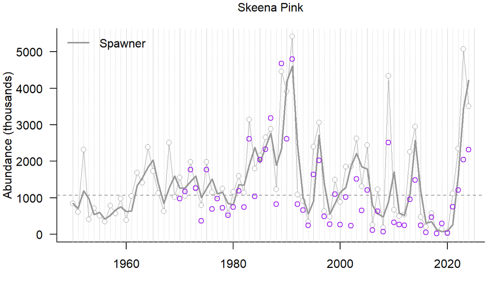

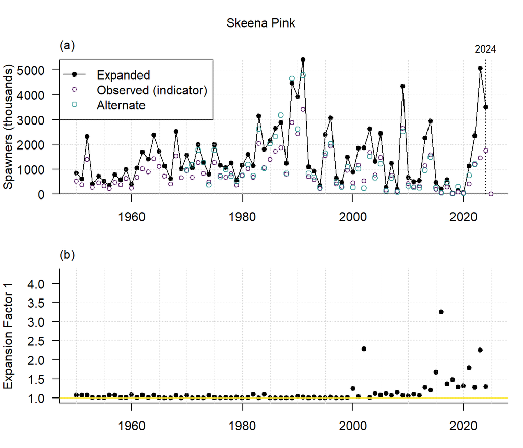

**Above:** (a) Time series of spawner abundances showing raw sum of counts for indicator streams (purple) and expanded estimates of spawner abudnance to indicator and non-indicator streams (black). This expanded time series is what is used to assess the current state and trends in spawner abundance for the region and species. Alternative time series from the PSC’s Northern Boundary Technical Committee Report (Appendix 32) is shown in bkue. (b) The values of Expansion Factor 1 that accounts for unmonitored indicator streams in a given year, and is calculated based on the proportional contribution of the unmonitored indicator stream(s) to the sum of all indicator streams in a (reference) decade. See section on Expansion Factors below for further details.

```r
## Process data
skeena.s <- sp[2, "Pink", ]
skeena.s <- skeena.s[!is.na(skeena.s)]

# Reformat data for SPS
skeena.s_sps <- data.frame(
    region = rep("Skeena", length(skeena.s)),
    species = rep("Pink", length(skeena.s)),
    year = as.numeric(names(skeena.s)),
    spawners = as.numeric(skeena.s),
    smoothedSpawners = NA,
    runsize = NA,
    smoothedRunsize = NA,
    source_id = rep(nuseds_id, length(skeena.s))
)

# Smoothing
skeena.s_sps$smoothedSpawners <- genSmooth(
    abund = skeena.s_sps$spawners,
    years = skeena.s_sps$year,
    genLength = genLength$gen_length[genLength$region == "Skeena" & genLength$species == "Pink"]
)

# Add to master sps dataframe
sps_data <- rbind(sps_data, skeena.s_sps)

# Generate standard figure
plot_abund(skeena.s_sps)
points(x=nbtc_tbl32$YEAR, y=nbtc_tbl32$PINK/1000, col="purple")
```

### 2.2.6 Central Coast

#### Chinook

For Central Coast Chinook, the PSC’s Chinook Technical Committee (CTC) reported escapement for two indicator stocks on the Central Coast: the Atnarko River and Rivers Inlet (Chinook Technical Committee 2025). Rivers Inlet is monitored “using an index of escapements to the Wannock, Kilbella, and Chuckwalla rivers” (Chinook Technical Committee 2025). Because monitoring of Central Coast Chinook reported in NuSEDS has recently declined, expansions from spawner surveys are unreliable. As such, in 2025 we moved to using a composite indicator equal to the sum of the Atnarko River (`Total esc.`) and Rivers Inlet index reported by the CTC in Appendix Table B3.

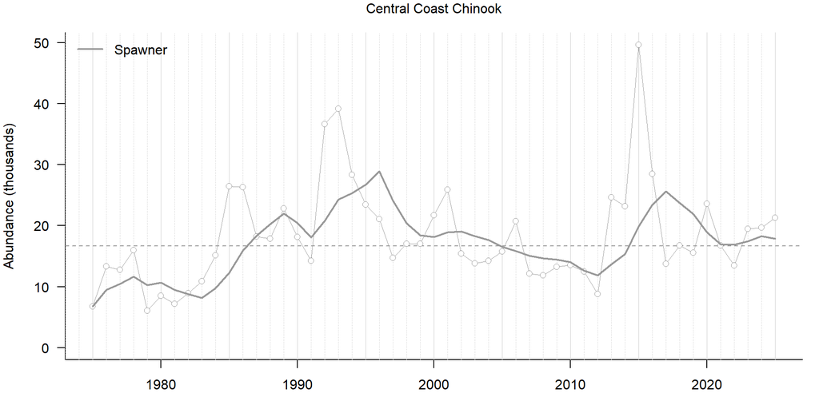

**Above:** Spawner abundance of Central Coast chinook salmon. The raw data is shown by points and the smoothed metric by solid lines. Dashed horizonal lines represent the long-term average.

```r
## Load data ---
# TCCHINOOK Table B3
cc_ctc <- readxl::read_xlsx(here("data/TCCHINOOK-2026-Appendix-B-Escapement-Detailed.xlsx"), sheet = "B3", range = "H5:K55", col_types = "numeric", col_names = c("Atnarko_Total_esc", "Atnarko_CV", "Atnarko_Wild", "Rivers_Inlet")) %>%
    mutate(Year = c(1975:2025))

# Reformat data for SPS
ccck_sps <- data.frame(
    region = rep("Central Coast", length(cc_ctc$Year)),
    species = rep("Chinook", length(cc_ctc$Year)),
    year = cc_ctc$Year,
    spawners = cc_ctc$Atnarko_Total_esc + cc_ctc$Rivers_Inlet,
    smoothedSpawners = NA,
    runsize = NA,
    smoothedRunsize = NA,
    source_id = rep(ctc_id, length(cc_ctc$Year))
)

# Smoothing
ccck_sps$smoothedSpawners <- genSmooth(
    abund = ccck_sps$spawners,
    years = ccck_sps$year,
    genLength = genLength$gen_length[genLength$region == "Central Coast" & genLength$species == "Chinook"]
)

# Add to master sps dataframe
sps_data <- rbind(sps_data, ccck_sps)

#Generate standard figure
plot_abund(ccck_sps)
```

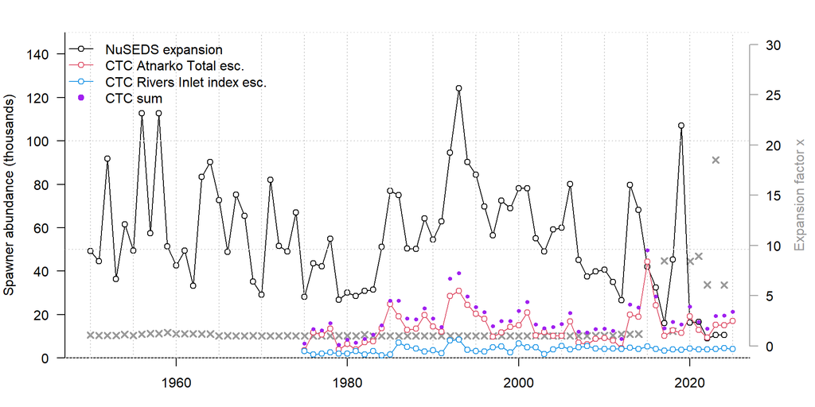

**Above:** Comparison of Chinook escapements on the Central Coast. The sum of Atnarko escapement (red) and Rivers Inlet escapement index (blue) from the CTC (purple points) was used in 2025. The expanded data from NuSEDS, not used, are in black with expansion factors used shown by grey ‘x’

```r
## Code to generate index comparison plot:
# Expanded spawner estimate
ccck_ex <- readRDS(here("output/expanded-spawners/Central Coast-spawners.rds"))[2, "Chinook", ]
yrs <- as.numeric(names(ccck_ex))

e <- readRDS(here("output/expanded-spawners/Central Coast-expansion-factors.rds"))[[1]]

# TCCHINOOK Table B3
cc_ctc <- readxl::read_xlsx(here("data/TCCHINOOK-2026-Appendix-B-Escapement-Detailed.xlsx"), sheet = "B3",
                                                        range = "H5:K55", col_types = "numeric",
                                                        col_names = c("Atnarko_Total_esc", "Atnarko_CV",
                                                                                    "Atnarko_Wild", "Rivers_Inlet")) %>%
    mutate(Year = c(1975:2025))

par(mar = c(3,4,2,4))
plot(yrs, e$exp1, pch = 4, bty = "n", xaxt = "n", yaxt = "n", xlab = "", ylab = "", col = grey(0.6), ylim = c(0, 30), lwd = 2)
axis(side = 4, col = grey(0.6), las = 1)
mtext(side = 4, line = 2.5, "Expansion factor x", col = grey(0.6))
par(new = TRUE)

plot(yrs, ccck_ex*10^-3, "o", pch = 21, bg = "white", bty = "l", xlab = "", ylab = "Spawner abundance (thousands)", ylim = c(0, 150), las = 1, yaxs = "i")
abline(v = seq(1950, 2025, 5), lty = 3, col = grey(0.8))
abline(h = seq(0, 150, 50), lty = 3, col = grey(0.8))
points(cc_ctc$Year, cc_ctc$Atnarko_Total_esc*10^-3, "o", pch = 21, bg = "white", col = 2)
points(cc_ctc$Year, cc_ctc$Rivers_Inlet*10^-3, "o", pch = 21, bg = "white", col = 4)
points(cc_ctc$Year, cc_ctc$Atnarko_Total_esc*10^-3 + cc_ctc$Rivers_Inlet*10^-3, pch = 19, col = "purple", cex = 0.6)

legend("topleft", col = c(1,2,4, "purple"), c("NuSEDS expansion", "CTC Atnarko Total esc.", "CTC Rivers Inlet index esc.", "CTC sum"), pch = c(rep(21, 3), 19), pt.bg = "white", lwd = c(rep(1, 3),NA), bty = "n")
```